# Communicate-Data-Findings-Ford-GoBike-System

## by Mohamed Abdelkader

## Investigation Overview

> Explore data and Understand how it correlate each other and bring best out of it ..

## Dataset Overview

> This data set includes information about individual rides made in a bike-sharing system covering the greater San Francisco Bay area.. Bay Wheels is a regional public bicycle sharing system in California's San Francisco Bay Area. It was established as Bay Area Bike Share in August 2013. As of January 2018, the Bay Wheels system had over 2,600 bicycles in 262 stations across San Francisco, East Bay and San Jose.  
> In June 2017 the system was officially re-launched as Ford GoBike in a partnership with Ford Motor Company.

## (Visualization 1)

> most of bike users are around 30 and the more old age the less users ..  
> most users below 40 years, few users between 40 and 60, and very few users above 60.

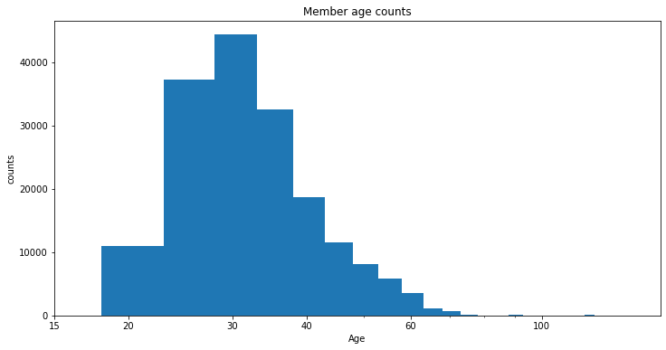

## (Visualization 2)

> it's max used in Thursday and least at weekend (SAT AND SUN).  
> it's peak of using is at the early morning at 8 am where people foing to schools and work etc.. and at 5 pm while returing homes ..  
> And ofc rarely used at night and early morning and average using is in day time between 8 am and 5 pm.

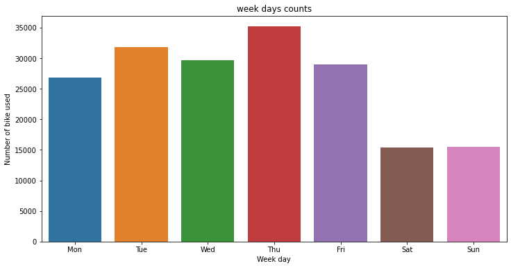

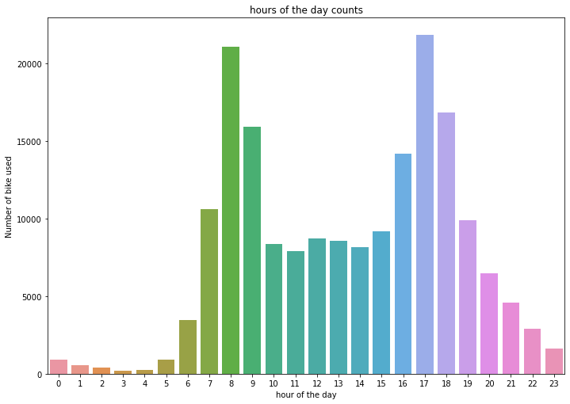

## (Visualization 3)

> as we see males have lower average durtion and women have higher average duration of trips.

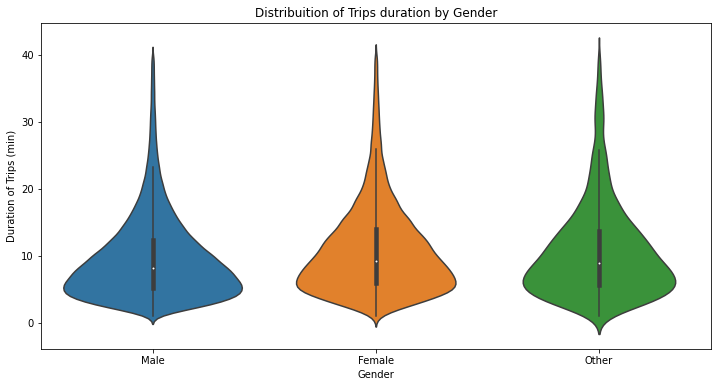

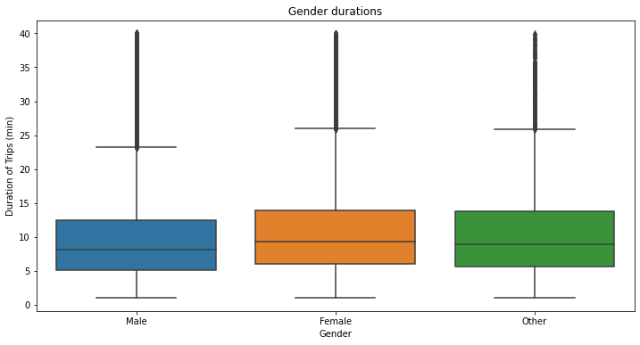